# Final Report Analysis: Recovery Coaches

Survey analysis output for cohorts 1 and 2 combined

Published

April 3, 2024

This html displays the key outputs of the analysis for the final sample of *N* = 72 recovery coaches. The table of contents on the left can be used to navigate across descriptive statistic categories. *Please note that response rates are still being calculated and will be included in the final report draft

## Coaches Descriptive Statistics (N = 72)

### Age

```
  dem_age  n proportion          Age
1       1  6 0.08333333        18-29
2       2 20 0.27777778        30-39
3       3 20 0.27777778        40-49
4       4 10 0.13888889        50-59
5       5 10 0.13888889        60-69
6       6  2 0.02777778        70-79
7    <NA>  4 0.05555556 Missing Data
```

### Gender

```
  dem_gender  n proportion                  Gender
1          1 19 0.26388889                    Male
2          2 41 0.56944444                  Female
3          3  3 0.04166667              Non-binary
4          4  5 0.06944444 Prefer to self describe
5          5  1 0.01388889       Prefer not to say
6       <NA>  3 0.04166667            Missing Data
```

### Race

```
  dem_race  n proportion                      Race
1        1 41 0.56944444                     White
2        2  9 0.12500000 Black or African American
3        3  2 0.02777778   Am Indian/Alaska Native
4        4  2 0.02777778 Asian or Pacific Islander
5        5  2 0.02777778                     Other
6     <NA> 16 0.22222222              Missing Data
```

### Ethnicity

```
  dem_ethnicity  n proportion Hispanic_Latino_Spanish_origin
1             1  4 0.05555556                            Yes
2             2 61 0.84722222                             No
3          <NA>  7 0.09722222                   Missing Data
```

### Education

```
  dem_education  n proportion                 HighestEducation
1             3  2 0.02777778                 Some high school
2             4 17 0.23611111   High school grad or equivalent
3             5 31 0.43055556 Some college or technical school
4             6 18 0.25000000                 College graduate
5             7  1 0.01388889                Prefer not to say
6          <NA>  3 0.04166667                     Missing Data
```

### Training Hours

**How many hours of recovery coaching training have you received from {organization}**

```
  training  n proportion HighestEducation
1        1  4 0.05555556             None
2        2  1 0.01388889    Less than 1hr
3        3  1 0.01388889           1-4hrs
4        4  5 0.06944444           5-8hrs
5        5 27 0.37500000          9-16hrs
6        6 23 0.31944444           17+hrs
7     <NA> 11 0.15277778     Missing Data
```

### Training Delivery

**Did someone at your organization deliver the training, or was it delivered by someone outside of the organization?**

```
  train_deliver  n proportion                         TrainingDelivery
1             1 28 0.38888889             Instructor from Organization
2             2 26 0.36111111 Instructor from outside the Organization
3             3  4 0.05555556                               Don't Know
4          <NA> 14 0.19444444                             Missing Data
```

### Training Manual

**Did the training use a specific curriculum or manual?**

```
  TrainingManualUsed  n proportion TrainingDelivery
1                  1 34  0.4722222              Yes
2                  2  8  0.1111111               No
3                  3 16  0.2222222       Don't Know
4               <NA> 14  0.1944444     Missing Data
```

### Training Helpfulness

**How helpful was the training?** Responses were recorded on a 4-point Likert scale: Very Helpful, Helpful, Somewhat Helpful, and Not At All Helpful.

```
  train_helpful  n proportion TrainingHelpfulness
1             1 50 0.69444444        Very Helpful
2             2  7 0.09722222             Helpful
3          <NA> 15 0.20833333        Missing Data
```

### Abilities

**Please rate the following statements based on whether each factor has increased or decreased for you since becoming a [Recovery Coach title].**

- **My knowledge of risk factors that lead to substance use disorder**
- **My ability to help individuals with substance use disorder**
- **My confidence, self-esteem, or self-management**
- **Skills like teamwork, communication, leadership, or technical skills**
- **My health, well-being, or fitness**
- **My sense of community and belonging**
- **My own ability to stay in recovery**

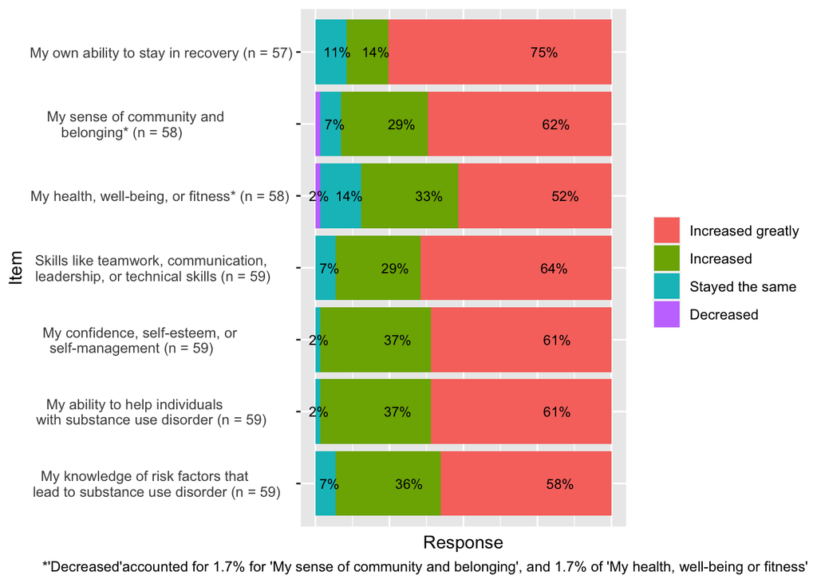

### Culturally Appropriate Treatment Plans

**The treatment plans I develop with my clients reflect their culture and worldviews. (Select the response that best fits your answer.)** Responses were recorded on a 5-point Likert scale: Completely Very well Somewhat Not very well Not at all

```
  CulturalPlans  n proportion
1    Completely 25 0.34722222
2     Very well 27 0.37500000
3      Somewhat  5 0.06944444
4 Not very well  1 0.01388889
5    Not at all  1 0.01388889
6  Missing Data 13 0.18055556
```

### Service Connections for Clients

**What other supports do you connect clients to? (Select all that apply)** Emergency shelters Food services Employment services Physical or behavioral health providers Other services (please specify): I do not connect individuals to outside resources

```
# A tibble: 6 × 5
  Item                  Response Count Proportion Service
  <chr>                 <fct>    <int>      <dbl> <chr>
1 service_connections_1 1           42     0.583  Emergency services
2 service_connections_2 1           49     0.681  Food services
3 service_connections_3 1           47     0.653  Employment services
4 service_connections_4 1           47     0.653  Physical or behavioral health…
5 service_connections_5 1           18     0.25   Other
6 service_connections_6 1            2     0.0278 None
```

### Client Frequency

**How often do you see each of the clients you work with?** Daily One day a week or more One or two days a month A couple of times per year Less than two times per year

```
             ClientFrequency  n proportion
1                      Daily 14 0.19444444
2               1+ days/week 28 0.38888889
3              1-2days/month 14 0.19444444
4 A couple of times per year  2 0.02777778
5 Less than 2 times per year 14 0.19444444
```

### Client Hours

**On average, how much time do you spend with each client per week?** Less than 1 hour 1-4 hours 5-8 hours 9-16 hours 17+ hours

```
   ClientHours  n proportion
1         <1hr 15 0.20833333
2       1-4hrs 37 0.51388889
3       5-8hrs  2 0.02777778
4       17+hrs  6 0.08333333
5 Missing Data 12 0.16666667
```

### Client Interaction Mode

**How do you interact with clients? (Select all that apply.)**  
In-person meetings Check-in calls Video calls (Zoom, Skype, FaceTime, etc.) Text messages Emails Other (please specify):

```
# A tibble: 6 × 5
  Item         Response Count Proportion Mode
  <chr>        <fct>    <int>      <dbl> <chr>
1 serve_mode_1 1           59     0.819  In-person meetings
2 serve_mode_2 1           33     0.458  Check-in calls
3 serve_mode_3 1           17     0.236  Video calls
4 serve_mode_4 1           30     0.417  Text messages
5 serve_mode_5 1           23     0.319  Emails
6 serve_mode_6 1            6     0.0833 Other
```

### Reason for Becoming Coach

**Why did you choose to become a [PRC title]? (Select all that apply.)**  
Desire to help people seeking recovery from a substance use disorder As an alternative to full-time paid employment My own lived experience or recovery motivated me To help my community To learn new skills I enjoy working with people Other (please specify):

```
# A tibble: 7 × 5
  Item         Response Count Proportion Reason
  <chr>        <fct>    <int>      <dbl> <chr>
1 prc_reason_1 1           53     0.736  Desire to help people seeking recovery…
2 prc_reason_2 1            7     0.0972 As an alternative to full-time paid em…
3 prc_reason_3 1           47     0.653  My own lived experience of recovery mo…
4 prc_reason_4 1           41     0.569  To help my community
5 prc_reason_5 1           38     0.528  To learn new skills
6 prc_reason_6 1           35     0.486  I enjoy working with people
7 prc_reason_7 1            2     0.0278 Other
```

### Benefits of Being a Coach

**How much do you agree or disagree that you get these benefits out of being a [PRC title]?** - Satisfaction from helping individuals with substance use disorders enter long-term recovery,  
- Satisfaction from improving the health of my community.  
Responses were likert scale:  
Strongly agree  
Agree  
Neither agree nor disagree  
Disagree  
Strongly disagree

```
# A tibble: 4 × 6
  Item                Response Count Proportion Benefit         Reason
  <chr>               <fct>    <int>      <dbl> <chr>           <chr>
1 agree_prcbenefits_1 1           49      0.681 HelpIndividuals Strongly agree
2 agree_prcbenefits_1 2           10      0.139 HelpIndividuals Agree
3 agree_prcbenefits_2 1           49      0.681 ImproveHealth   Strongly agree
4 agree_prcbenefits_2 2            8      0.111 ImproveHealth   Agree
```

### Satisfaction with Aspects of Being a Coach

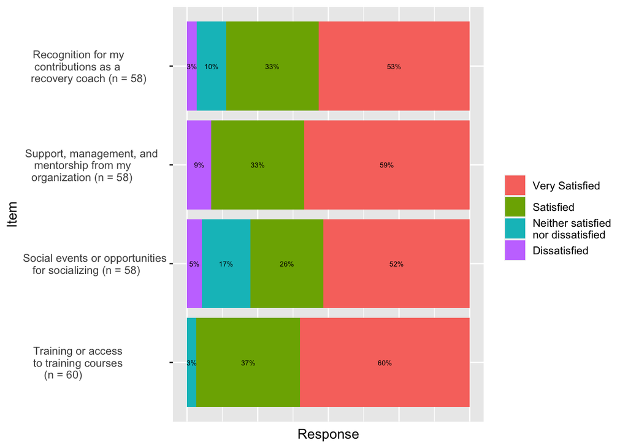

## Full/part-time employment

```
  prc_fulltime  n proportion
1            1 57 0.79166667
2            2 11 0.15277778
3         <NA>  4 0.05555556
```

## Years as volunteer

```
  prc_years  n proportion  ClientHours
1         1 43 0.59722222        <1 yr
2         2 25 0.34722222       1-5yrs
3      <NA>  4 0.05555556 Missing Data
```

## Long-term recovery of coaches

**Are you currently in long-term recovery?**

```
  prc_recovery  n proportion          Recovery
1            1 52 0.72222222               Yes
2            2  7 0.09722222                No
3            3  1 0.01388889 Prefer not to say
4         <NA> 12 0.16666667      Missing Data
```

## Number of clients seen on weekly basis

```
  serve_number  n proportion Number_of_Clients
1            1 14 0.19444444                <5
2            2 23 0.31944444              5-10
3            3 14 0.19444444             11-20
4            4  8 0.11111111             21-30
5            5  2 0.02777778               31+
6         <NA> 11 0.15277778      Missing Data
```

### Client session format

```
# A tibble: 4 × 4
# Groups:   Item [4]
  Item       Response Count Proportion
  <chr>      <fct>    <int>      <dbl>
1 services_1 1           27          1
2 services_2 1           22          1
3 services_3 1           16          1
4 services_4 1            4          1
```

## Certification

```
   prc_certify  n proportion
1          Yes 30 0.41666667
2           No 26 0.36111111
3        Other  5 0.06944444
4 Missing Data 11 0.15277778
```